# Analysis of Single-Cell RNA-seq - Session 2

Niamh Errington

Last modified: 30 Jan 2023

# Introduction

In session 1, we read in our data and created a seurat object. We then performed some quality control, and subset the data according to the QC plots we generated. In this session, we are going to normalise the data, select the most variable features and scale,regressing out unwanted sources of variation.

## Learning Objectives

- Build code to normalise data
- Identify unwanted sources of variation in the data & find variable genes
- Execute SCTransform to transform data and regress out unwanted variation
- Build code to integrate data & form clusters

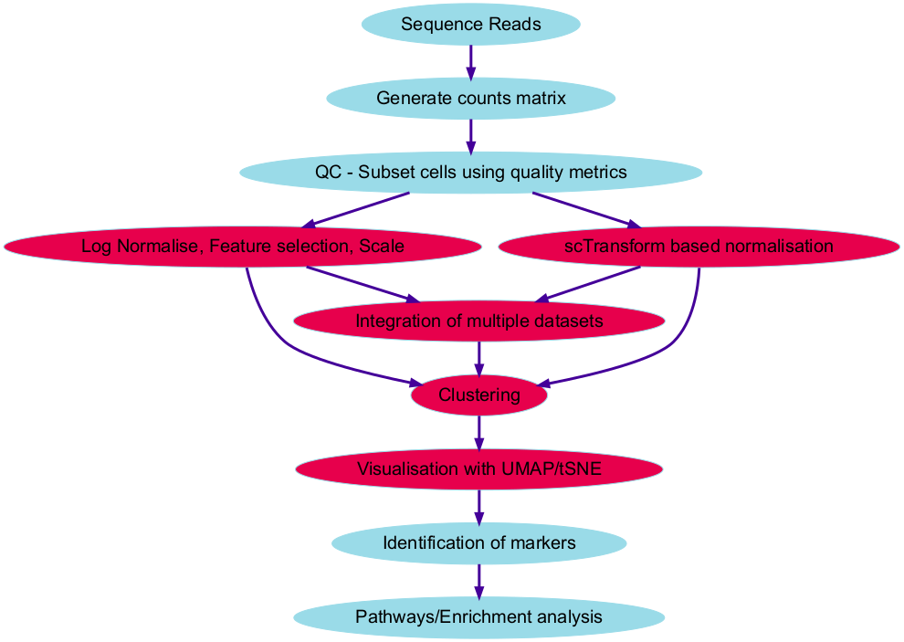

# Normalisation

Now that we have our high quality cells, there are still a few steps left before we can cluster cells.

Firstly, we normalise the expression values. Then we identify highly variable genes. Next, data is scaled and unwanted effects regressed out. Then we integrate samples together, and finally, we do dimension reduction.

```r
#Re-load libraries
library(Seurat)
library(tidyverse)
```

```r
#Reload R objects if necessary
filtered_data <- readRDS("Robjects/seurat_filtered.RDS")
```

# Sources of Variation

- Goal is to identify clusters that show interesting biological variation between cells.
- Differences in sequencing depth is common to bulk seq
- Cell cycle is often influential
- Can identify cell cycle status using a few key genes

We want to be able to check for potential sources of unwanted variation before we do our normalisation and regresssion of unwanted variation. One of the most common sources of unwanted variation is cell cycle. Before we can check for this, we need the counts to be comparable between cells, currently each cell has a different number for `nCount_RNA` (the number of UMI).

```r
summary(filtered_data$nCount_RNA)
```

```
   Min. 1st Qu.  Median    Mean 3rd Qu.    Max.
    815    2679    3892    6045    7236   48368
```

We can use the `NormalizeData` function to use log normalisation to take the sequencing depth into account. `nCount_RNA` for each gene is divided by the total `nCount_RNA` for that cell, and then multiplied by the scale factor (default 10,000). This is natural-log transformed using log1p.

```r
filtered_data <- NormalizeData(filtered_data)
```

We determine which phase of the cell cycle a cell is in, based on it’s expression of phase markers. We’ve included the list we need here as a txt, but some other organisms can be found [here](https://github.com/hbc/tinyatlas/tree/master/cell_cycle), as well as a resource [here](https://hbctraining.github.io/scRNA-seq_online/lessons/cell_cycle_scoring.html) for finding cell markers for other organisms.

```r
cc_genes <- read.delim("regev_lab_cell_cycle_genes.txt")[,1]
s_genes <- cc_genes[1:43]
g2m_genes <- cc_genes[44:97]

seurat_phase <- CellCycleScoring(filtered_data,
                                 g2m.features = g2m_genes,
                                 s.features = s_genes)
# View cell cycle scores and phases assigned to cells
View(seurat_phase@meta.data)
```

Each cell is given a score, based on it’s expression of the phase markers using the `CellCycleScoring()` function. We now have 3 new columns. The highest score between S.Score and G2M.Score determines the phase. If both columns are negative, then the phase is G1. A bar plot shows us how many cells are in each phase.

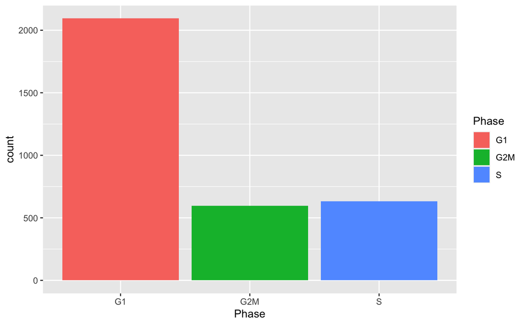

```r
as_tibble(seurat_phase[[]]) %>% ggplot(aes(x = Phase, fill = Phase))+ geom_bar()
```

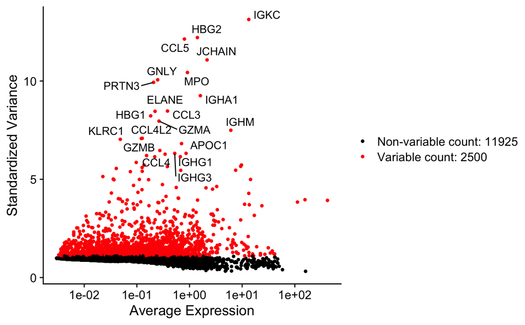

```r
# Identify the most variable genes
seurat_phase <- FindVariableFeatures(seurat_phase,
                     selection.method = "vst",
                     nfeatures = 2500, #default
                     verbose = FALSE)

# Identify the top 20 most highly variable genes. We need the VariableFeatures function to pull the names
top20 <- head(VariableFeatures(seurat_phase), 20)

# The variablity can be accessed using the HVFInfo function
var.data <- as_tibble(HVFInfo(seurat_phase), rownames = "Gene") %>% mutate(Included = Gene %in% VariableFeatures(seurat_phase))

# Plot the variable features
VarPlot<- VariableFeaturePlot(seurat_phase)

LabelPoints(plot = VarPlot, points = top20, repel = TRUE,  xnudge = 0, ynudge = 0)
```

We’re finally ready to see if cell cycle is a driving factor of variation, using PCA. After finding the most variable gene features (above), we scale the data to account for these highly variable genes. The `ScaleData` function will do this for us, such that the mean expression in each cell is 0, with a variance of 1. This ensures highly-expressed genes are not dominating, as we don’t want the high expression values to be the only thing reflected in the highly variable genes.

```r
# Scale the counts
seurat_phase <- ScaleData(seurat_phase)
# Perform PCA
seurat_phase <- RunPCA(seurat_phase)
```

```
PC_ 1
Positive:  CA2, CA1, PRDX2, GYPA, HEMGN, GYPB, TFRC, UBAC1, AHSP, BLVRB
       RFESD, TMEM56, MINPP1, RHAG, HMBS, SLC4A1, SLC25A37, UROD, TFDP1, IFI27
       KLF1, CPOX, SMIM1, FECH, HBD, ANK1, SNCA, ALAS2, GLRX5, SPTA1
Negative:  TMSB4X, CD52, LTB, CD3D, CORO1A, RPS2, IL32, RPL37A, CD3G, TRAC
       AIF1, S100A10, PLAC8, MT-CO2, LSP1, TRBC2, TRBC1, COTL1, LCK, C1orf162
       IL7R, GIMAP7, CTSS, MT-ND2, ACTG1, CD27, TYROBP, NR4A2, VIM, ZFP36
PC_ 2
Positive:  CD3D, IL32, LTB, CD3G, TRAC, TRBC1, CD52, TRBC2, GYPC, SOX6
       RHCE, HEMGN, GYPA, GYPE, IL7R, GYPB, TSPO2, LCK, TRIM10, EPB42
       RHAG, CD27, SPTA1, DMTN, CPOX, SLC4A1, TMEM56, CD8B, CA2, RHD
Negative:  CST3, GAPDH, LYZ, TYROBP, HLA-DRB1, LGALS1, MNDA, RP11-1143G9.4, FCER1G, VIM
       HLA-DRA, LST1, GSTP1, SRGN, S100A11, CSTA, CTSS, GRN, TYMP, KLF4
       FCN1, S100A9, ANXA2, VCAN, CD74, TNFSF13B, S100A4, S100A8, PYCARD, AP1S2
PC_ 3
Positive:  FCN1, S100A9, MNDA, CD36, TYROBP, S100A6, S100A8, VCAN, LYZ, RP11-1143G9.4
       S100A11, FCER1G, HBM, S100A4, SERPINA1, FTL, S100A12, CSTA, BLVRB, FGL2
       RETN, CXCL8, CD14, HBA1, HBD, TYMP, LGALS3, HBA2, PSAP, CST3
Negative:  IGLL1, PTMA, STMN1, CD24, VPREB1, VPREB3, SOX4, CD79B, PDLIM1, CD79A
       TCL1A, CMTM8, VDAC1, HNRNPA1, HMGA1, CD9, HMGB1, TYMS, MSI2, UHRF1
       EBF1, PARP1, IGLL5, NPM1, FAM129C, CD38, MYB, RCSD1, HNRNPA1L2, IGHM
PC_ 4
Positive:  APOC1, FAM178B, RPL37A, RPS2, HSP90AB1, CNRIP1, EPCAM, SYNGR1, RPL23, KCNH2
       NMU, AKR1C3, ALDH1A1, HSPB1, HSPD1, PRSS57, MYC, RPL7A, FKBP4, CYTL1
       MT-ND2, NPM1, RPLP0, RHOBTB3, SRM, LDHB, NME1, NME4, HSPE1, C1QBP
Negative:  CD79B, TCL1A, CD24, NUSAP1, VPREB3, TOP2A, MKI67, UBE2C, IGHM, CD9
       CD79A, VPREB1, KIAA0226L, HMGB2, HLA-DRA, IGLL5, FAM129C, CENPF, CFAP73, IRF4
       AURKB, IGLL1, CDCA8, GTSE1, CENPA, PDLIM1, RGS2, PTTG1, ASPM, CD74
PC_ 5
Positive:  S100A12, SNHG25, CFD, CSTA, CD14, VCAN, FCN1, MGST1, G0S2, CDA
       SERPINA1, S100A8, PTMA, KIAA0101, CFP, MCEMP1, CMTM8, PLBD1, RETN, QPCT
       S100A9, CTB-61M7.2, AIF1, ITGAM, FAM178B, SPI1, CSF3R, RBP7, FPR1, CLEC7A
Negative:  GZMB, RGS1, CLIC3, IRF7, LILRA4, CCL5, GZMA, ARL4C, C12orf75, CCDC50
       IRF8, SCT, UGCG, PTPRS, ALOX5AP, CD69, IGKC, LGMN, HBA2, HBB
       CLEC4C, CTSW, HBA1, KLRB1, SLAMF7, ITM2C, SEL1L3, SERPINF1, NKG7, KLRD1
```

Let’s visualise the PCA. The plots for each phase look quite different, so we’ll need to regress out cell cycle variation.

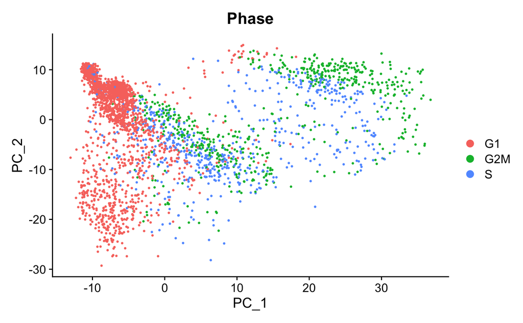

```r
# Plot the PCA colored by cell cycle phase
DimPlot(seurat_phase, reduction = "pca",group.by = "Phase")
```

Mitochondrial genes can also affect clusters.

```r
summary(seurat_phase$mito.ratio)
```

```
   Min. 1st Qu.  Median    Mean 3rd Qu.    Max.
0.00160 0.02036 0.03330 0.03454 0.04558 0.18848
```

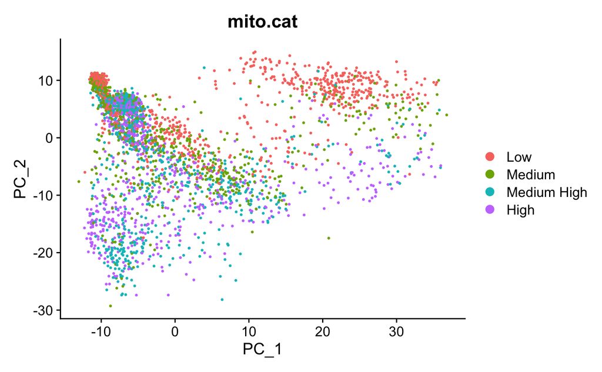

```r
seurat_phase$mito.cat <- cut(seurat_phase$mito.ratio, breaks=c(-Inf,0.02036  , 0.03330 ,0.04558 ,Inf),labels=c("Low","Medium","Medium High","High"))

DimPlot(seurat_phase,
        reduction = "pca",
        group.by= "mito.cat")
```

# SCTransform

We decide to regress for mitochondrial ratio, number of UMI and cell-cycle status. First we split the object into a list of subsetted objects, where there is 1 for each sample. This step might take a while.

SCTransform does the data normalisation, data scaling & finding of variable features. Sequencing depth is automatically regressed out, but it doesn’t hurt to include nUMI in our list of variables to regress so we can follow.

```r
seurat_split <- SplitObject(seurat_phase, split.by = "SampleName")

for(i in 1:length(seurat_split)){

  seurat_split[[i]] <- SCTransform(seurat_split[[i]],vars.to.regress = c("mito.ratio","nUMI","S.Score","G2M.Score") )
}
```

# Integration

Batch effect has not been addressed. This is potentially something that could be addressed within the SCTransform step we just performed, but regressing out assumes that the ‘batch effect’ is the same for all cells. As this is not normally the case, the seurat team developed a method specifically for dealing with this issue - integration. If our ultimate goal is to compare cell-type expression between groups, we’ll need to integrate the data. If you go back to look at older single cell papers, you’ll probably see that they haven’t done this step, but it is now recognised to be more important. It is optional, but recommended.

There are 4 steps for integration:

1. Select variable features for integration by taking the highly variable genes from each sample identified using SCTransform above, we can specify here that we want to use the 3000 most variable genes for integration.
2. Prepare the SCTransform object for integration
3. Identify ‘anchors’ between cells. These are mutual nearest neighbours across the data. For each cell, the closest neighbour is identified based on gene expression. If the neighbour’s closest neighbour is the original cell, these will be marked as ‘anchors’ for the data.
4. Integrate the conditions / samples by using the anchors along with their corresponding scores to transform cell expression values.

```r
# Select variable features for integration
integ_features <- SelectIntegrationFeatures(object.list = seurat_split, nfeatures = 3000)

# Prepare the SCTransform object for integration
seurat_split <- PrepSCTIntegration(object.list = seurat_split, anchor.features = integ_features)
```

```
  |                                                  | 0 % ~calculating
  |+++++++++++++++++++++++++                         | 50% ~01s
  |++++++++++++++++++++++++++++++++++++++++++++++++++| 100% elapsed=02s
```

```r
# Identify mutual nearest neighbours across datasets
integ_anchors <- FindIntegrationAnchors(object.list = seurat_split,
                                        normalization.method = "SCT",
                                        anchor.features = integ_features)
```

```
Finding all pairwise anchors
```

```
  |                                                  | 0 % ~calculating
```

```
Running CCA
Merging objects
Finding neighborhoods
Finding anchors
    Found 4031 anchors
Filtering anchors
    Retained 3378 anchors
```

```
  |++++++++++++++++++++++++++++++++++++++++++++++++++| 100% elapsed=27s
```

```r
# Integrate across samples
seurat_integrated <- IntegrateData(anchorset = integ_anchors,normalization.method = "SCT")
```

```
Merging dataset 1 into 2
Extracting anchors for merged samples
Finding integration vectors
Finding integration vector weights
Integrating data
```

Now we can run an analysis on the integrated object.

```r
# Run PCA, UMAP & TSNE
seurat_integrated <- RunPCA(object = seurat_integrated)
```

```
PC_ 1
Positive:  IL32, LTB, CD3D, RPS27, CD52, TRAC, IL7R, TRBC1, CD3G, CD3E
       IFITM1, CD7, RPS29, RPL34, TRBC2, BCL11B, RPL21, RPL10, RPL13, EVL
       CD8B, CD69, RPS12, RPS18, LCK, LINC00861, FLT3LG, RPS15A, TCF7, CD27
Negative:  LYZ, RP11-1143G9.4, LGALS1, CST3, TYROBP, MNDA, FCER1G, S100A9, SRGN, S100A4
       S100A8, FCN1, S100A6, S100A11, LST1, VIM, HLA-DRA, CTSS, HLA-DRB1, VCAN
       ANXA1, MS4A6A, RETN, CSTA, TYMP, CD74, KLF4, CYBA, CXCL8, ANXA2
PC_ 2
Positive:  IGLL1, SOX4, CD79B, VPREB3, STMN1, CD24, VPREB1, HLA-DRA, TCL1A, CD74
       PTMA, TCF4, CD79A, IGHM, ACTG1, CXCR4, CD9, TIFA, RCSD1, IGLL5
       PDLIM1, PAX5, EBF1, HLA-DPB1, MSI2, HMGB1, MZB1, PCDH9, HMGN2, VDAC1
Negative:  HBA1, AHSP, CA1, HBA2, HBD, GYPA, PRDX2, HBM, HEMGN, GYPB
       BLVRB, CA2, SLC25A37, SLC4A1, HBB, S100A6, IFI27, TFRC, CD36, ALAS2
       S100A4, HMBS, MGST3, S100A9, H1F0, S100A8, LYZ, RHAG, UROD, UBAC1
PC_ 3
Positive:  IL32, TMSB4X, CD3D, TRAC, CD3G, CD52, IFITM1, FYB, CRIP1, TRBC1
       CD3E, CD2, IL7R, TRBC2, S100A10, TMSB10, TNFAIP3, B2M, LTB, PTPRC
       LCK, COTL1, JUNB, CCL5, GIMAP4, CD7, SYNE2, EVL, CALM1, GIMAP7
Negative:  SPINK2, CD74, KIAA0125, PRSS57, HLA-DRA, SOX4, HBA1, HBD, HBA2, AHSP
       TCF4, ANKRD28, MEF2C, GYPA, SMIM24, CA1, HBM, BCL11A, C1QTNF4, HLA-DPB1
       AVP, CDK6, HEMGN, GYPB, SLC25A37, HLA-DRB1, EGFL7, CYTL1, RP11-620J15.3, CD34
PC_ 4
Positive:  SERPINB1, PRSS57, SPINK2, ANKRD28, MGST1, IGLL1, CDK6, GAPDH, C1QTNF4, NPM1
       S100A8, MIF, NGFRAP1, AIF1, RPS18, MPO, SMIM24, S100A9, EBPL, KIAA0125
       MYB, PRDX1, EGFL7, RETN, RPL34, CLEC11A, ENO1, CD34, TKT, LAPTM4B
Negative:  CD74, HLA-DPB1, HLA-DPA1, HLA-DRA, HLA-DRB1, HLA-DQA1, HLA-DQB1, JCHAIN, IRF8, HBA1
       C12orf75, CCDC50, IGKC, PLD4, RGS1, GYPA, CA1, HBD, HLA-DMB, HBA2
       UGCG, HLA-DMA, AHSP, IRF7, GPR183, GYPB, MS4A1, ARL4C, CA2, HBM
PC_ 5
Positive:  C12orf75, PLAC8, IRF8, PLD4, SPINK2, LGALS1, PLEK, ALOX5AP, ITM2C, GSTP1
       ARL4C, FCER1A, SAMHD1, APP, MPO, VAMP8, LSP1, PPIB, CCDC50, IGFBP7
       FABP5, PRSS57, RNASE6, LGMN, VIM, SCT, RUNX2, ANXA2, PTPRS, C1orf186
Negative:  CD79B, TCL1A, VPREB3, CD24, CD79A, IGHM, IGLL5, VPREB1, PAX5, MS4A1
       CD9, FCN1, RGS2, PCDH9, BACH2, S100A12, TIFA, CD72, CD19, FTL
       RCSD1, S100A8, SERPINA1, BTG1, GLRX, IGHD, RP11-164H13.1, S100A9, CD14, MARCKS
```

```r
seurat_integrated <- RunTSNE(object = seurat_integrated)
seurat_integrated <- RunUMAP(object = seurat_integrated, dims = 1:30, verbose = FALSE) #Theres quite a lot of output for this command, if we don't want that, we can use the verbose = FALSE
```

**Exercise:** It’s a good idea to check what these clusters look like. Make a plot to examine the new PCA and UMAP for the new integrated object. Split the plot so there is 1 for each sample group. Then make another for cell phase.

We might want to check the numbers as well. We expect the majority of cell type clusters to be present in both samples, however depending on the experiment we might expect condition specific cell types instead.

```r
# Extract identity and sample information from seurat object to determine the number of cells per cluster per sample
n_cells <- FetchData(seurat_integrated,
                     vars = c("ident", "orig.ident")) %>%
        dplyr::count(ident, orig.ident) %>%
        tidyr::spread(ident, n)

# View table
View(n_cells)
```

# Determine the ‘dimensionality’

An elbow plot is a way to help determine how many PCs we should look at to ensure the majority of variation in the data is captured. The elbow plot helps to visualise the standard deviation of each PC. The location of the ‘elbow bend’ provides us with a good guess for how many PCs we should include. Let’s plot the top 30 dimensions.

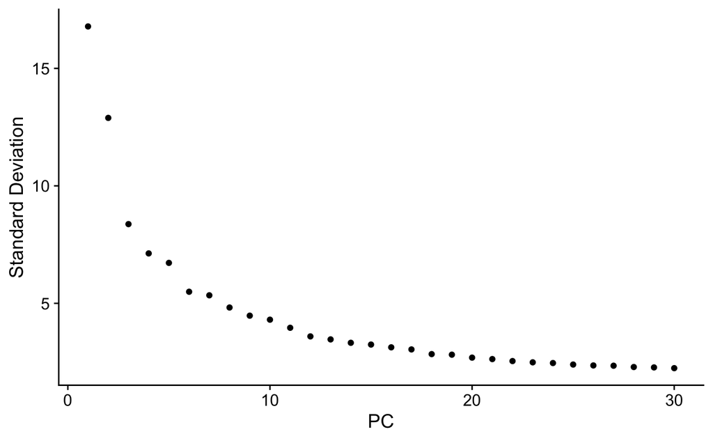

```r
# Plot the elbow plot
ElbowPlot(object = seurat_integrated, ndims = 30)
```

When we interpret the elbow plot, we use the ‘elbow’ to determine the point at which an extra PC is bringing diminishing returns and is no longer adding a meaningful reduction in standard deviation. As in this example, the precise elbow is not always easy to spot. We can also look at dimensionality heatmaps to give us another view. These show the PCA weightings for the highest and lowest weighted genes, against the genes most influenced by the PC. We interpret them by looking for a clear structure. Once that structure is lost, we’re probably no longer adding useful information. If we plot the first 10, where we can see each PC is still adding information, we can see what they look like when they’re informative.

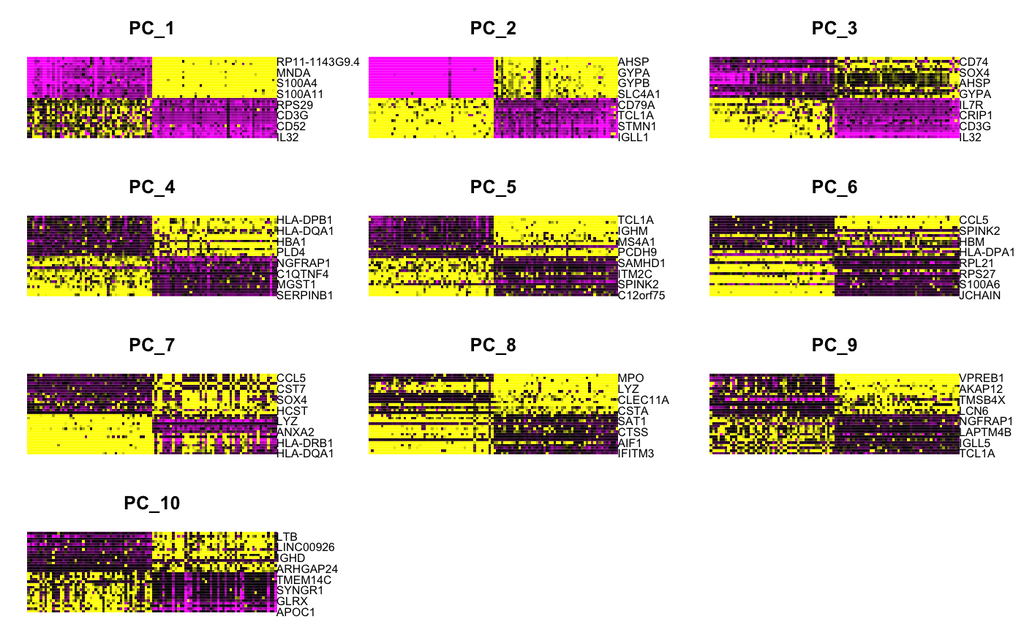

```r
DimHeatmap(seurat_integrated, dims = 1:10, cells = 100, balanced = TRUE)
```

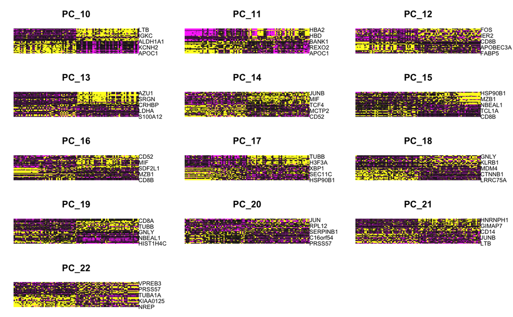

```r
DimHeatmap(seurat_integrated, dims = 10:22, cells = 100, balanced = TRUE)
```

We can look at the most variable genes driving the PCA:

```r
print(x = seurat_integrated[["pca"]],
      dims = 1:5,
      nfeatures = 5)
```

```
PC_ 1
Positive:  IL32, LTB, CD3D, RPS27, CD52
Negative:  LYZ, RP11-1143G9.4, LGALS1, CST3, TYROBP
PC_ 2
Positive:  IGLL1, SOX4, CD79B, VPREB3, STMN1
Negative:  HBA1, AHSP, CA1, HBA2, HBD
PC_ 3
Positive:  IL32, TMSB4X, CD3D, TRAC, CD3G
Negative:  SPINK2, CD74, KIAA0125, PRSS57, HLA-DRA
PC_ 4
Positive:  SERPINB1, PRSS57, SPINK2, ANKRD28, MGST1
Negative:  CD74, HLA-DPB1, HLA-DPA1, HLA-DRA, HLA-DRB1
PC_ 5
Positive:  C12orf75, PLAC8, IRF8, PLD4, SPINK2
Negative:  CD79B, TCL1A, VPREB3, CD24, CD79A
```

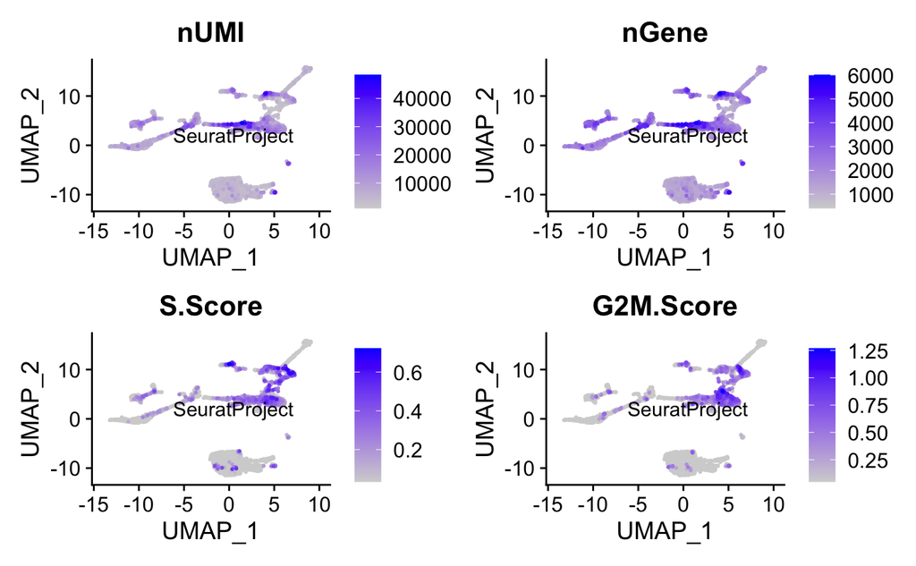

```r
FeaturePlot(seurat_integrated,
            reduction = "umap",
            features = c("nUMI", "nGene", "S.Score", "G2M.Score"),
            pt.size = 0.4,
            order = TRUE,
            min.cutoff = 'q10',
            label = TRUE)
```

# Find clusters

We decided from our Elbow plot how many dimensions to use in our clustering approach. We’re going to do this in 2 steps. The first command is going to construct a K-nearest neighbour (KNN) graph using the `FindNeightbors()` function. Part of the input here is based on the elbow plot, where we’ve decided to use the top 21 dimensions. The second step is to use the `FindClusters()` function, which performs the actual clustering. The resolution argument here sets the ‘granularity’ for downstream clustering. A higher value results in more clusters. Seurat recommends picking a value between 0.4-1.2 for single cell sets ~3K cells.

```r
seurat_integrated <- FindNeighbors(seurat_integrated, dims = 1:21, verbose = FALSE)
seurat_integrated <- FindClusters(seurat_integrated, verbose = FALSE, resolution = 0.5)
```

We can use the `DimPlot` function again to plot our new clusters.

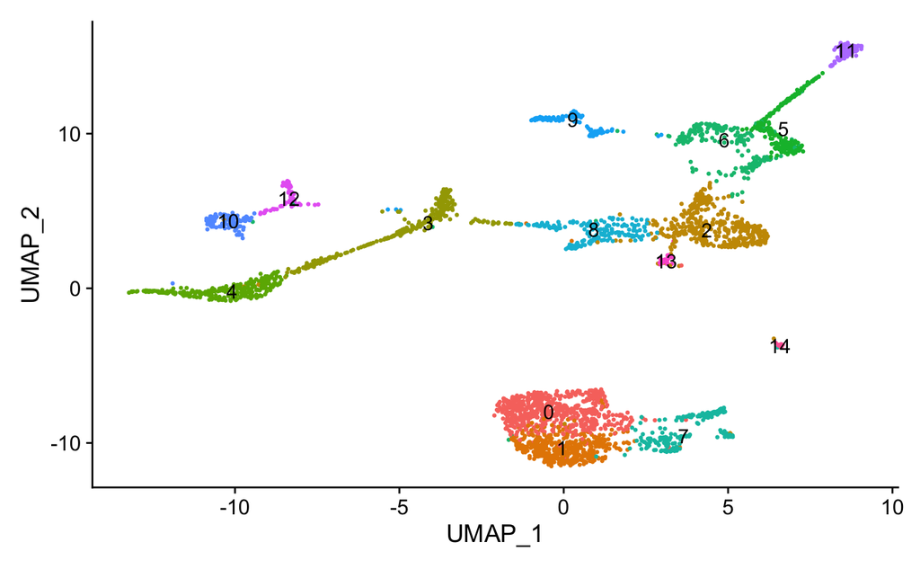

```r
DimPlot(seurat_integrated, label = TRUE) + NoLegend()
```

Save the Seurat data as an R object again.

```r
saveRDS(seurat_integrated, file = "Robjects/seurat_integrated.RDS")
```